# Student Outcomes Under Elected and Appointed Superintendents

Thursday, December 4, 2014

## Overview of U.S. School Districts

- Approximately 14,500 School Districts
- ~14,350 School Districts Appoint Their Superintendent
- Meanwhile, ~150 School Districts Elect Their Superintendent

## Full Map of Mississippi School Districts

[figure not shown]

65 of Mississippi's 151 School Superintendents Are Elected (~43%)

## Map of Mississippi School Districts

[figure not shown]

65 of Mississippi's 151 School Superintendents Are Elected (~43%)

## Data

| Variables | Explanation | Year | Source |
| --- | --- | --- | --- |
| Enrolled100s | Total District Enrollment (k-12) in 100s | 2014 | NCES |
| Student-to-Teacher Ratio | Ratio of students to teachers in the district | 2012 | NCES |
| Poverty Percentage | Percent of 5-17 year olds in poverty in the district | 2012 | 2012 Census |
| Graduation Rates | 2014 Graduation rate of the 2009 cohort | 2014 | MSDE |
| Composite Score | Composite score of all SATP tests | 2014 | MSDE |

## Summary Statistics Appointed

**Summary Statistics for Appointed Districts**

| Statistic | N | Mean | St. Dev. | Min | Max |
| --- | --- | --- | --- | --- | --- |
| Enrolled100s | 73 | 23.1 | 15.7 | 1.6 | 62.6 |
| CompositeScore | 73 | 654.6 | 4.1 | 646.0 | 665.0 |
| PovertyPct | 73 | 36.9 | 10.2 | 16 | 56 |
| GradRate | 73 | 73.3 | 10.4 | 48.5 | 94.0 |
| StudentTeacherRatio | 73 | 14.9 | 1.5 | 10.6 | 19.7 |
| Algebra | 73 | 654.6 | 4.0 | 646 | 665 |
| Biology | 73 | 651.3 | 5.2 | 638 | 662 |
| History | 73 | 647.4 | 3.8 | 639 | 656 |
| English | 73 | 649.4 | 3.5 | 643 | 657 |

## Summary Statistics Elected

**Summary Stats for Elected Districts**

| Statistic | N | Mean | St. Dev. | Min | Max |
| --- | --- | --- | --- | --- | --- |
| Enrolled100s | 65 | 31.8 | 32.8 | 2.4 | 193.8 |
| CompositeScore | 65 | 654.8 | 3.3 | 648.0 | 665.0 |
| PovertyPct | 65 | 33.2 | 9.7 | 12 | 56 |
| GradRate | 65 | 73.5 | 8.4 | 51.5 | 90.5 |
| StudentTeacherRatio | 65 | 14.9 | 1.4 | 10.8 | 18.5 |
| Algebra | 65 | 654.8 | 3.5 | 647 | 665 |
| Biology | 65 | 651.4 | 4.1 | 642 | 659 |
| History | 65 | 647.4 | 3.6 | 638 | 654 |
| English | 65 | 649.9 | 3.7 | 641 | 658 |

## Test Score Distributions

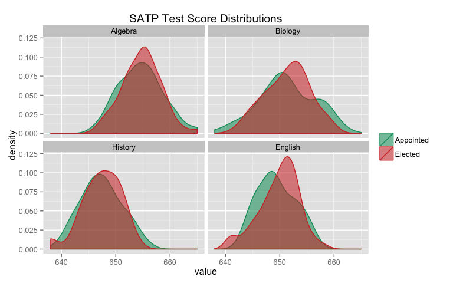

## Graduation Rate Distributions

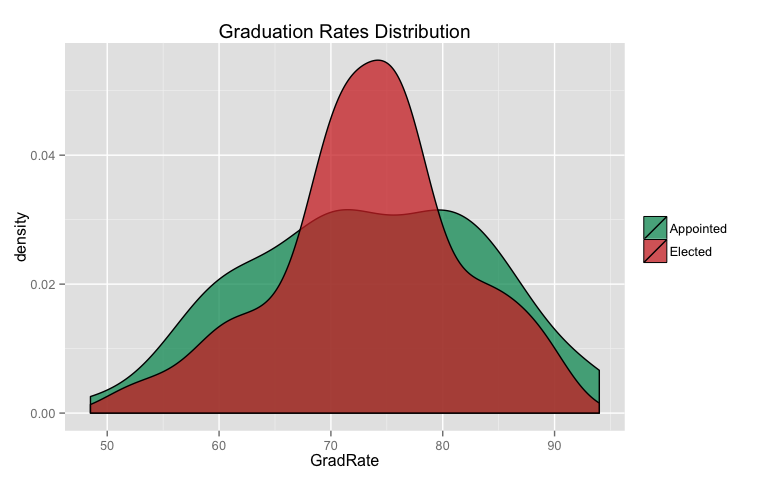

## Poverty Rate Distributions

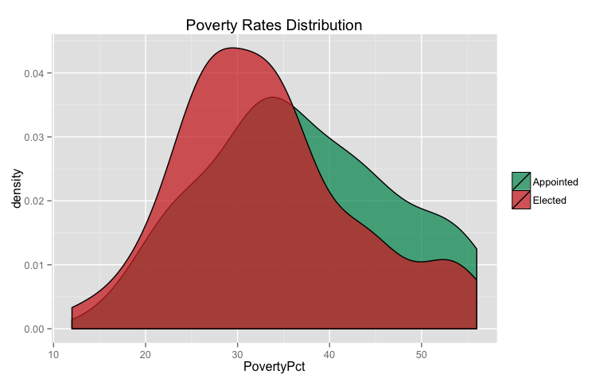

## Enrollment Size Distributions

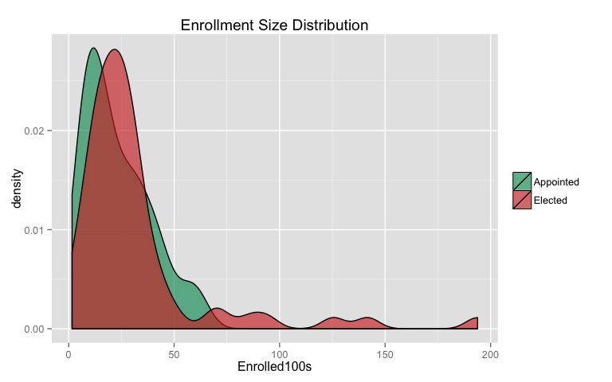

## Regression Output

|  | *Dependent variable:* |
| --- | --- |
|  | GradRate |
| Elected Superintendent | -4.304* |
|  | (2.316) |
| Pct Students in Poverty | -0.424*** |
|  | (0.078) |
| Student-to-Teacher Ratio | 1.437*** |
|  | (0.532) |
| Enrollment | -0.129* |
|  | (0.068) |
| Elected:Enrollment | 0.122* |
|  | (0.072) |
| Constant | 70.625*** |
|  | (8.059) |
| Observations | 138 |
| R<sup>2</sup> | 0.233 |
| Adjusted R<sup>2</sup> | 0.204 |
| Residual Std. Error | 8.424 (df = 132) |
| F Statistic | 8.002*** (df = 5; 132) |
| *Note:* | p<0.1; p<0.05; p<0.01 |

Call: lm(formula = GradRate ~ EA10 + PovertyPct + StudentTeacherRatio + Enrolled100s + EA10:Enrolled100s, data = completeclean)

Residuals: Min 1Q Median 3Q Max -17.7055 -5.3917 -0.7791 4.0842 24.7064

Coefficients: Estimate Std. Error t value Pr(>|t|)  
(Intercept) 70.62483 8.05886 8.764 8.09e-15 EA10 -4.30373 2.31641 -1.858 0.06541 .  
PovertyPct -0.42400 0.07782 -5.448 2.41e-07 StudentTeacherRatio 1.43663 0.53152 2.703 0.00778 ** Enrolled100s -0.12854 0.06752 -1.904 0.05914 .  
EA10:Enrolled100s 0.12160 0.07200 1.689 0.09361 .  
— Signif. codes: 0 '**' 0.001 '**' 0.01 '' 0.05 '.' 0.1 ' ' 1

Residual standard error: 8.424 on 132 degrees of freedom Multiple R-squared: 0.2326, Adjusted R-squared: 0.2035 F-statistic: 8.002 on 5 and 132 DF, p-value: 1.291e-06

## Modeling Graduation Rates

[output not shown]

## Predicted Graduation Rates For Appointed Districts

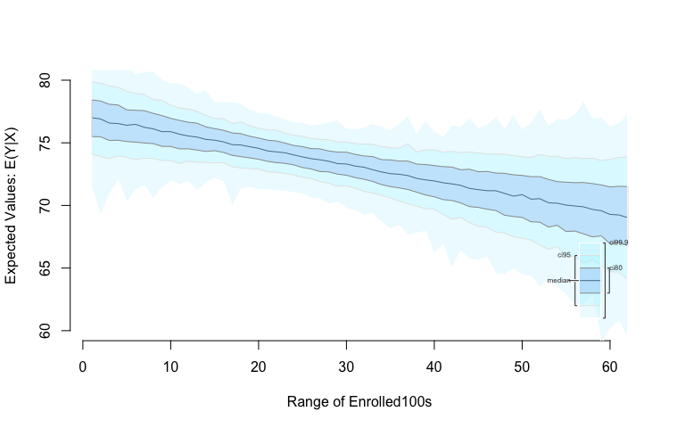

## Predicted Graduation Rates Elected Districts

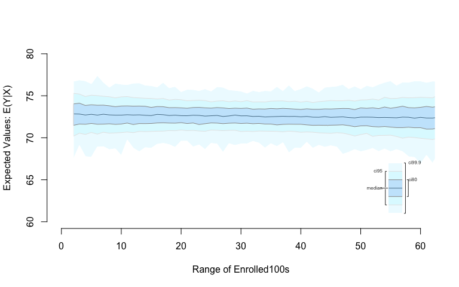

## In Summary

- On Paper, Student Outcomes In Appointed and Elected Districts Look The Same
- Once You Control For Differences, Things Look Differently
- Specifically, Graudation Rates in Elected Districts are ~4 Pct Pts Lower Than In Appointed Districts

## But Most Importantly

[figure not shown]

**(Enrollment) SIZE MATTERS!**